# Analise de Regressao Linear - Caso Imobiliario

Paulo R

# 1. Introdução

Este relatório apresenta uma análise de regressão linear aplicada ao mercado imobiliário, com foco em identificar como diferentes fatores influenciam o preço por m2.

O objetivo é oferecer uma visão executiva, clara e orientada à tomada de decisão.

A base utilizada contém 413 registros, com identificadores variando de 1 a 413. Sem duplicidades, a base se apresenta consistente para a análise proposta.

# 2. Caracterização da Base Imobiliária

## Mapa de Calor das Relações Entre Variáveis

A Correlação entre Reais_m2 e o Deslocamento_metro_Km é forte e tem tendência de queda no preço.

A Correlação entre Reais_m2 e o Tempo_Construcao é fraca e também tem tendência de queda de preço.

A Correlação entre Reais_m2 e a quantidade de Comercios_quadra é ligeiramente forte, com tendência de aumento de preço.

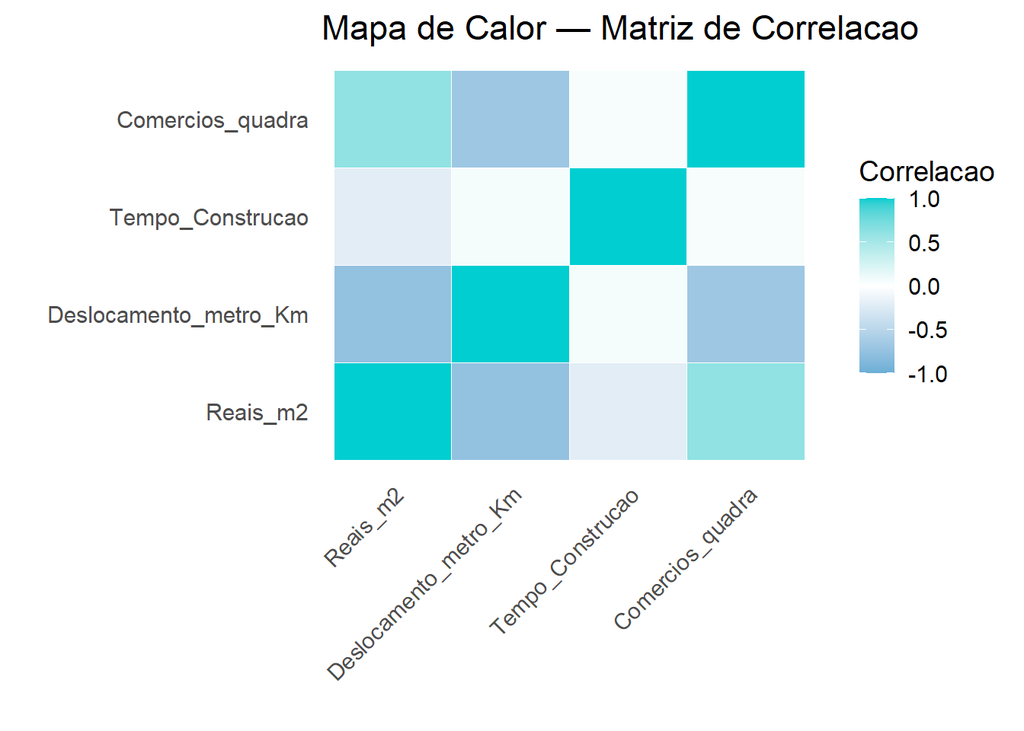

## Observações executivas

### Variável observada (Reais_m2)

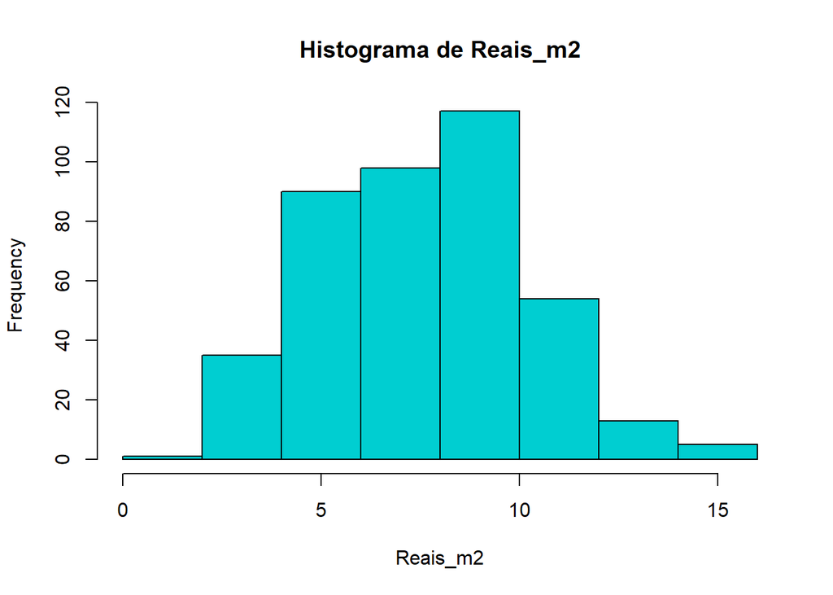

### Resumo estatístico das variáveis

```
##     Reais_m2      Tempo_Construcao Deslocamento_metro_Km Comercios_quadra
##  Min.   : 1.520   Min.   : 0.00    Min.   :0.769         Min.   : 0.000
##  1st Qu.: 5.540   1st Qu.: 9.00    1st Qu.:1.383         1st Qu.: 1.000
##  Median : 7.680   Median :16.10    Median :1.512         Median : 4.000
##  Mean   : 7.558   Mean   :17.73    Mean   :1.560         Mean   : 4.102
##  3rd Qu.: 9.320   3rd Qu.:28.20    3rd Qu.:1.777         3rd Qu.: 6.000
##  Max.   :15.660   Max.   :43.80    Max.   :2.142         Max.   :10.000
```

#### Reais_m2

O preco por m2 apresenta variacao consideravel, com metade dos imoveis situados entre aproximadamente 5,5 mil e 9,3 mil reais por m2. A mediana de 7,68 mil indica que o mercado tem valores moderados, mas ha unidades que chegam a mais de 15 mil por m2, mostrando presenca de imoveis de padrao mais elevado.

#### Tempo_Construcao

O tempo de construção dos imóveis é bem variado, mas metade deles se concentra entre 9 e 28 anos, mostrando um portfólio com unidades tanto mais novas quanto mais antigas.

#### Deslocamento_metro_Km

A distância até o metrô é relativamente estável, concentrada entre 1,3 km e 1,8 km, com poucas unidades muito próximas ou muito distantes. Isso sugere uma localização relativamente homogênea em termos de acesso ao transporte.

#### Comercios_quadra

A oferta de comércio no entorno varia de forma moderada onde a maior parte dos imóveis está em áreas com 1 a 6 comércios por quadra, mas existem regiões com até 10 estabelecimentos, indicando zonas mais movimentadas.

**Sintese geral das variaveis:** Em conjunto, as variáveis mostram um mercado relativamente homogêneo em localização, mas com variação relevante em preço e idade dos imóveis, o que justifica o uso de regressão para identificar os fatores que mais influenciam o valor.

# 3. Modelagem

### 3.1 Visão geral do modelo

O modelo ajustado considera as seguintes variáveis explicativas:

- Distância até o metrô
- Tempo de construção
- Quantidade de comércios na quadra

Desempenho do modelo:

- **R² ajustado:**

Mesmo após a penalização do modelo devido ao número de variáveis, o modelo ainda explica cerca de 61.687% da variação do preço por m².

- **MAPE:**

O modelo erra em média 17.5% no valor previsto por m², o que é comum e razoável, considerando que o preço de um imóvel tem alta variabilidade.

- **Erro típico (RSE):**

O erro típico deste modelo oscila em torno de mais ou menos 1.62 mil/m².

Coeficientes do Modelo de Regressao

[output not shown]

Mesmo adotando critérios estatísticos mais rigorosos, com níveis de confiança de 99% ou até 99,9%, todas as variáveis do modelo permanecem estatisticamente significativas.

Isso reforça que os efeitos observados são consistentes e não resultam de variações aleatórias da base.

### 3.2 Como cada variável explicativa do modelo influencia o preço por m²

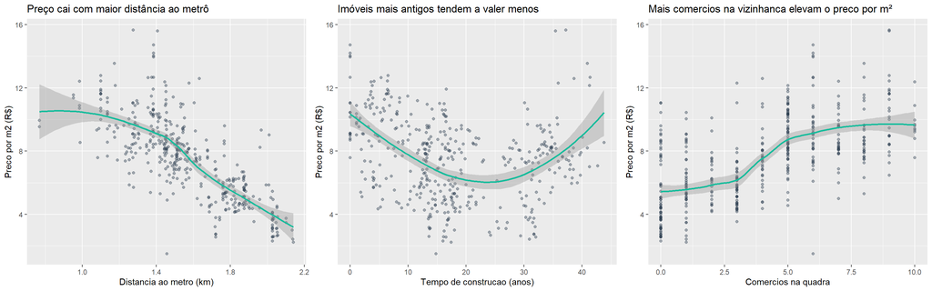

### 3.3 Formula matematica do modelo

O modelo ajustado pode ser representado pela seguinte equacao linear:

$$\small
Reais\_m2 = 16.49
\; - \; 5.74 \cdot Deslocamento\_metro\_Km
\; - \; 0.04 \cdot Tempo\_Construcao
\; + \; 0.18 \cdot Comercios\_quadra$$

Essa expressao mostra como cada variavel contribui para o preco por m2, mantendo as demais constantes.

# 4. Diagnóstico dos resíduos

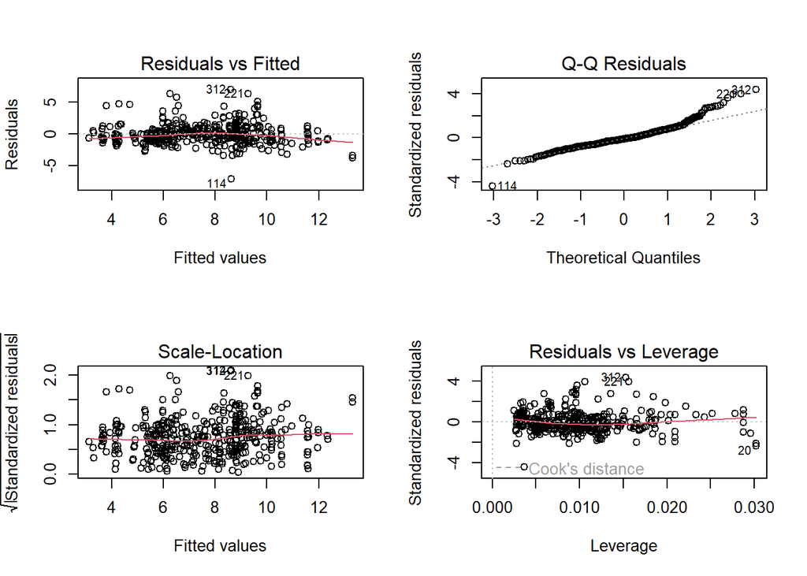

Os gráficos indicam um comportamento de resíduos compatível com os pressupostos básicos da regressão linear, sem violações severas de normalidade ou homocedasticidade.

# 5. Conclusões

- A distância ao metrô apresenta relação negativa com o preço por m².
- A presença de comércios na região tende a elevar o valor dos imóveis.
- O modelo é uma regressão linear múltipla, interpretável e adequada para uso exploratório e apoio à decisão no contexto imobiliário.

Este relatório é uma visão executiva; toda a análise detalhada, testes adicionais e experimentações estão documentados em scripts técnicos deste projeto.

# 6. Insights de Negócio e Potencial da Metodologia

O mercado imobiliário foi apenas o *case* utilizado para demonstrar a aplicação.  
O produto real é a metodologia preditiva, que pode ser aplicada em qualquer setor que possua dados históricos.

Principais entregas da metodologia:

- Identifica os fatores que mais influenciam o resultado
- Quantifica o impacto de cada variável
- Permite simulações “e se” para apoiar decisões
- Gera insights acionáveis em linguagem executiva
- Pode ser replicada para varejo, saúde, RH, logística, indústria, marketing e finanças

**Mensagem central:** a metodologia é o ativo principal e pode ser adaptada ao contexto de cada cliente.

# 7. Contato e Informações Profissionais

Para projetos de modelagem preditiva, analise de dados ou consultoria personalizada, entre em contato:

[Falar no WhatsApp](https://api.whatsapp.com/send/?phone=5513991245656&text=Olá%20Paulo,%20gostaria%20de%20saber%20mais%20sobre%20seus%20serviços%20de%20consultoria%20preditiva.&type=phone_number&app_absent=0)

**Email:** paulo.pconsult@gmail.com  
**LinkedIn:** https://www.linkedin.com/in/paulo-data-driven/  
**GitHub:** https://paulopconsult-bit.github.io/

Fico a disposicao para desenvolver modelos, estudos e solucoes de dados aplicados ao seu negócio.